# Assignment-2

ugob-ifig-jase-eqem Emalee Schuler

Question 1

What happens when the following code is executed?

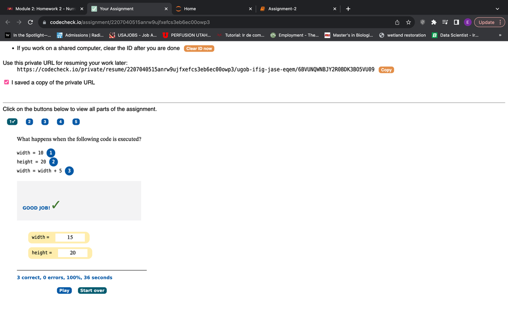

Question 2

Rearrange the following lines to produce a program snippet that computes and prints the number of coins in a piggybank, given the number of nickels, dimes, and quarters. Be sure to place the comments so that they truthfully describe the steps within the program.

[figure not shown]

Question 3

Complete this program that computes the area and perimeter of a rectangle with given width and height. If a rectangle has width w and height h, then the area is wh, and the perimeter is 2(w + h).

```python
#Initialize values for width and height

width = 10
height = 20

# Compute the area and perimeter of a rectangle

area = width * height
perimeter = 2 * ( width + height)

# Print Results
print("Area: ", area)
print("Perimeter: ", perimeter)
```

```
Area:  200
Perimeter:  60
```

[figure not shown]

Question 4

In order to paint a wall that has a number of windows, we want to know its area. Each window has a size of 2 ft by 3 ft. Write a program that reads the width and height of the wall and the number of windows, using the prompts

Wall width: Wall height: Number of windows: Then print the area. The width and height of the wall should be entered as a floating-point value and the number of windows as an integer.

```python
# Prompt for and read the width and height
# and the number of windows

Wall_width = float(input("Wall width: "))
Wall_height = float(input("Wall height: "))
Number_of_windows = int(input("Number of windows: "))

# Calculate the area of the wall
Wall_area = Wall_width * Wall_height

# Calculate the area covered by windows
Window_area = Number_of_windows * (2 * 3)  # Each window is 2 ft by 3 ft

# Calculate the remaining wall area after deducting the window area
area = Wall_area - Window_area

# Compute the area of the wall without the windows

print("Area:", area)
```

[output not shown]

[figure not shown]

Question 5

Give the value for each of the expressions below assuming the following definitions:

greeting = "Hello" location = "World" In your anwers to this problem, be sure to put double quotation marks around any string values.

[figure not shown]